# Final Project

Melanie Kos

# Read in data, cleaning genie

Read in the dataframes and cleaning genies

```r
subject_df <- read_csv("/Users/tur61139/Library/CloudStorage/OneDrive-TempleUniversity/IMENSA/unpacked_from_D/subject_df.csv")
fast_long_df <- read_csv("/Users/tur61139/Library/CloudStorage/OneDrive-TempleUniversity/IMENSA/unpacked_from_D/subject_fast_long_df.csv")
original_interview_df <- read_excel("/Users/tur61139/Library/CloudStorage/OneDrive-TempleUniversity/IMENSA/ORIGINAL + CLEANED IMENSA Exit Interview Data.xlsx", sheet = "Original")
cleaned_interview_df <- read_excel("/Users/tur61139/Library/CloudStorage/OneDrive-TempleUniversity/IMENSA/ORIGINAL + CLEANED IMENSA Exit Interview Data.xlsx", sheet = "Cleaned")

melanie_genie <- function(data, # Input data
                          text_col = NULL, # Indicate name of text column for a df input
                          id_col = NULL, # Indicate name of subject ID column for a df input
                          lemmatize = TRUE, #Lemmatize words on or off
                          omit_stops = TRUE, # Remove stops
                          remove_numbers = TRUE, # Remove numbers
                          remove_number_words = TRUE, # Remove written out numbers
                          remove_roman = TRUE, # Remove roman numerals
                          strip_possessives = TRUE, # Amend singular and plural possessives
                          normalize_abbrev = TRUE, # Replace common abbreviations with full word
                          dash_mode = c("prefix_merge", "split", "remove"),
                          # Prefix_merge = merge common list of common prefixes on hyphen (ie re-do becomes redo, well-being becomes well being)
                          # Split = all hyphens become spaces (ie re-do becomes re do, well-being becomes well being)
                          # Remove = all hyphens are removed (ie re-do becomes redo, well-being becomes wellbeing)
                          return_base_text = FALSE) # Return the fully cleaned base text along with two df outputs

{

  dash_mode <- match.arg(dash_mode)

  library(dplyr)
  library(tidyr)
  library(stringr)
  library(stringi)
  library(textstem)
  library(tidytext)

  ###############################################################
  ### Data type check; if data is a df, indicate the text column
  ###############################################################
  if (is.data.frame(data)) {

    if (is.null(text_col)) {
      stop("If data is a dataframe, you must supply text column name")}

    if (!text_col %in% names(data)) {
      stop(paste("Column", text_col, "not found in df"))}

    x <- as.character(data[[text_col]])
    if (is.null(id_col)) {
      id_values <- seq_len(nrow(data))
    } else {
      if (!id_col %in% names(data))
        stop(paste("Column", id_col, "not found in dataframe"))

      id_values <- data[[id_col]]
    }

    df_base <- tibble(ID = id_values, id_row_orig = seq_along(x), text = x)

  } else {

    # Character vector input
    x <- as.character(data)
    df_base <- tibble(ID = seq_along(x), id_row_orig = seq_along(x), text = x)
  }

  # Load stopword and replacement lists from github
  load(url("https://github.com/Reilly-ConceptsCognitionLab/reillylab_publicdata/blob/main/Temple_stops25.rda?raw=true"))
  load(url("https://github.com/Reilly-ConceptsCognitionLab/reillylab_publicdata/blob/main/replacements_25.rda?raw=true"))
  ################################
  ### Below modules are always on:
  ################################

  # Normalize all text to UTF-8 encoding
  utf8_normalize <- function(x) {
    tryCatch(stringi::stri_enc_toutf8(as.character(x), is_unknown_8bit = TRUE, validate = TRUE),
             error = function(e)
               stringi::stri_encode(as.character(x), to = "UTF-8"))
  }

  # Remove any new lines, tabs, returns, etc.
  strip_control_characters <- function(x) {
    stringi::stri_replace_all_regex(x, "[\\p{C}]+", " ")
  }

  # Normalize apostrophes and quotation marks
  normalize_quotes <- function(x) {
    x <- str_replace_all(x, "[\u2018\u2019\u2032\u0027\u00b4\u201b]","'") # Manage apostrophes to be straight
    x <- str_replace_all(x,"[\u201c\u201d\u0022\u2033\u02dd\u201f\u201e]","[\u0022]") # Manage quotation marks to be straight
    x
  }

  #####################################
  ### Below modules are toggled on/off:
  #####################################

  # Normalize abbreviations (toggle on/off)
  normalize_abbrev_module <- function(x) {
    # Apply contractions replacement (only for non-NA values) (search x for contractions, replace with replacement phrase)
    x <- str_replace_all(x, setNames(replacements_25$replacement, replacements_25$word))

    # Manual change of popular abbreviations...
    x <- gsub("and/or", "and or", x)
    x <- gsub("\\bi\\.e\\.(?=\\W|$)", "that is", x, perl = TRUE)
    x <- gsub("\\betc\\.(?=\\W|$)", "etcetera", x, perl = TRUE)
    x <- gsub("vis-a-vis(?=\\W|$)", "visavis", x, perl = TRUE)
    x <- gsub("\\be\\.g\\.(?=\\W|$)", "for example", x, perl = TRUE)
    x <- gsub("\\bMr\\.(?=\\W|$)", "mister", x, perl = TRUE)
    x <- gsub("\\bMrs\\.(?=\\W|$)", "missus", x, perl = TRUE)
    x <- gsub("\\bMs\\.(?=\\W|$)", "miss", x, perl = TRUE)
    x <- gsub("\\bSr\\.(?=\\W|$)", "senior", x, perl = TRUE)
    x <- gsub("\\bJr\\.(?=\\W|$)", "junior", x, perl = TRUE)
    x <- gsub("\\bSte\\.(?=\\W|$)", "suite", x, perl = TRUE)
    x <- gsub("\\bCapt\\.(?=\\W|$)", "captain", x, perl = TRUE)
    x <- gsub("\\bProf\\.(?=\\W|$)", "professor", x, perl = TRUE)
    x <- gsub("\\bRev\\.(?=\\W|$)", "reverend", x, perl = TRUE)
    x <- gsub("\\bSt\\.(?=\\s+[A-Z])", "saint", x, perl = TRUE) # Saint (religious / place names), usually followed by capital letter for name
    x <- gsub("\\bSt\\.(?=\\s*[a-z0-9]|\\W|$)", "street", x, perl = TRUE) # Street (addresses), usually followed by non-capital letter or punctuation
    x <- gsub("\\bDr\\.(?=\\s+[A-Z])", "doctor", x, perl = TRUE) # Doctor, usually followed by capital letter for name
    x <- gsub("\\bDr\\.(?=\\s*[a-z0-9]|\\W|$)", "drive", x, perl = TRUE) # Drive (addresses), usually followed by non-capital letter or punctuation
    x
  }
```

```r
  # Normalize singular and plural possessives (toggle on/off)
  strip_possessives_module <- function(x) {
    x <- gsub("'s\\b", "", x) # Singular possessive (so no additional s at end of word)
    x <- gsub("s'\\b", "s", x) # Plural possessives (so no additional ss at end of word)
    x
  }

  # Remove roman numerals for chapters, etc. AND other numerals anywhere else (toggle on/off)
  remove_roman_module <- function(x) {
    # Remove chapter, section numerals
    x <- gsub("\\b(?i:(chapter|section|act|book|part))\\s+(?i:[ivxlcdm]+)(st|nd|rd|th)?(?=[[:punct:]]|\\s|$)", "", x, perl = TRUE)

    # Remove any remaining Roman numerals anywhere in text
    x <- gsub("\\b(?i:[ivxlcdm]+)(st|nd|rd|th)?\\b", "", x,perl = TRUE)
    x
  }

  # Remove all numeric numbers and suffix for written numbers (toggle on/off)
  remove_numbers_module <- function(x) {
    x <- gsub("\\b(\\d+)(st|nd|rd|th)\\b", "\\1", x, perl = TRUE)
    x <- gsub("[[:digit:]]", "", x)
    x
  }


  # Remove all written out numbers (toggle on/off)
  remove_number_words_module <- function(words) {
    number_stems <- "\\b(zero|one|two|three|four|five|six|seven|eight|nine|ten|eleven|twelve|thirteen|fourteen|fifteen|sixteen|seventeen|eighteen|nineteen|twenty|thirty|forty|fifty|sixty|seventy|eighty|ninety|hundred|thousand|million|billion)\\b"
    ifelse(str_detect(words, number_stems), NA_character_, words)
  }


  # Hyphen/dash module, 3 potential modes (also defined above):
  # Prefix_merge = merge common list of common prefixes on hyphen (ie re-do becomes redo, well-being becomes well being)
  # Split = all hyphens become spaces (ie re-do becomes re do, well-being becomes well being)
  # Remove = all hyphens are removed and squished (ie re-do becomes redo, well-being becomes wellbeing)
  dash_mode_module <- function(x, mode) {
    if (mode == "prefix_merge") {
      x <- gsub(
        "\\b(re|co|de|ex|pro|anti|non|self|pre|post|un|trans|quasi|dis|im|auto|hyper|neo|under|over|sub|mis|poly|mal|in|inter|com|bi|counter|be|good|to|with|a|al|be|for|fore|out)\\s*-\\s*",
        "\\1", x, ignore.case = TRUE, perl = TRUE)
      x <- gsub("(?<=\\p{L})-(?=\\p{L})", " ", x, perl = TRUE) # Any other words without above prefixes become two words
    }
    if (mode == "split") {
      x <- gsub("-", " ", x) # Split all hyphens into two words
    }
    if (mode == "remove") {
      x <- gsub("-", "", x) # Split all hyphens into one word
    }
    x
  }

  # Lemmatization module (toggle on/off)
  lemmatize_module <- function(text_vector) {
    textstem::lemmatize_strings(text_vector) # Note lemmatize_strings usage
  }

  # Remove stop words as defined in Temple_stops25 (toggle on/off, can also change stop word list...)
  omit_stops_module <- function(words) {
    stopwords <- tolower(Temple_stops25$word)
    ifelse(words %in% stopwords, NA_character_, words)
  }

  #############################################
  # Actual cleaning begins...
  #############################################
  df_base$text <- utf8_normalize(df_base$text)
  df_base$text <- strip_control_characters(df_base$text)
  df_base$text <- normalize_quotes(df_base$text)

  if (normalize_abbrev) {
    df_base$text <- normalize_abbrev_module(df_base$text)}

  if (strip_possessives) {
    df_base$text <- strip_possessives_module(df_base$text)}

  # Roman numeral removal BEFORE punctuation cleanup (so "I." "II." etc. are removed)
  if (remove_roman) {
    df_base$text <- remove_roman_module(df_base$text)}

  # Dash/hyphen handling
  df_base$text <- dash_mode_module(df_base$text, dash_mode)

  # Punctuation cleanup
  df_base$text <- gsub("\t|[[:punct:]]+", " ", df_base$text) # Remove tabs, punctuation, account for any missing spaces between punctuation

  # Lowercase and squish
  df_base$text <- str_to_lower(df_base$text) # Lowercase everything
  df_base$text <- str_squish(df_base$text) # Remove any empty spaces between words, line breaks, etc.

  # Digit removal and numeric suffix removal AFTER punctuation cleanup
  if (remove_numbers) {
    df_base$text <- remove_numbers_module(df_base$text)}

  # String-level lemmatization BEFORE tokenization
  if (lemmatize) {
    df_base$text <- lemmatize_module(df_base$text)}

  # Tokenization
  token_df <- df_base |>
    unnest_tokens(word_raw, text, drop = FALSE) |>
    mutate(id_row_postsplit = row_number(),
           word_lemma = word_raw)

  # Remove number words
  if (remove_number_words) {
    token_df <- token_df |>
      mutate(word_lemma = remove_number_words_module(word_lemma))}


  # Stopword toggle
  if (omit_stops) {
    token_df <- token_df |>
      mutate(word_clean = omit_stops_module(word_lemma))
  } else {
    token_df <- token_df |>
      mutate(word_clean = word_lemma)}

  # Remove single letters
  token_df <- token_df |>
    mutate(word_clean = ifelse(nchar(word_clean) <= 1, NA_character_, word_clean))

  # Counts
  token_df <- token_df |>
    mutate(word_lemma = ifelse(str_detect(word_lemma, "\\d"), NA_character_, word_lemma), # Make sure digits are removed
           word_clean = ifelse(str_detect(word_clean, "\\d"), NA_character_, word_clean)) |>
    group_by(ID, word_raw) |>
    mutate(n_raw = n()) |>
    ungroup() |>
    group_by(ID, word_clean) |>
    mutate(n_clean = ifelse(is.na(word_clean), NA_integer_, n())) |>
    ungroup()

  type_df <- token_df |>
    group_by(ID, word_raw, word_lemma, word_clean) |>
    summarise(n_raw = n(), .groups = "drop") |>
    left_join(token_df |>
                filter(!is.na(word_clean)) |>
                group_by(ID, word_raw) |>
                summarise(n_clean = n(), .groups = "drop"), by = c("ID","word_raw"))

  type_df <- type_df |>
    arrange(ID, desc(n_clean), desc(n_raw))


  # Return base text (fully cleaned string-level text) (toggle on/off)
  if (return_base_text) {
    list(base_text = df_base$text, token_df = token_df, type_df = type_df)
  } else {
    list(token_df = token_df, type_df  = type_df)
  }

}
```

# Prompt and animal key

Setting up the paired key for the FAST prompt terms, assigning them to `affect` or `control` terms and a `positive`, `negative`, or `neutral` valence. Also set up the animal key for the animal rankings, indicating which animals were depicted in the video content.

```r
prompt_key <- tibble(prompt = c("teardrop", "pain", "happiness", "mirror", "knife", "family", "politician", "chicken", "eggs", "rain", "earthquake", "fall",
             "crying", "suffering", "wellbeing", "reflection", "axe", "friends", "government", "cow", "milk", "sun", "hurricane", "spring"),

  prompt_class = c("affect_term", "affect_term", "affect_term", "control_term",
                   "control_term", "control_term", "control_term", "stimulus_content",
                   "stimulus_content", "control_term", "control_term", "control_term",
                   "affect_term", "affect_term", "affect_term", "control_term",
                   "control_term", "control_term", "control_term", "stimulus_content",
                   "stimulus_content", "control_term", "control_term", "control_term"),

  valence = c("negative", "negative", "positive", "neutral", "negative", "positive", "neutral", "neutral", "neutral", "neutral", "negative", "positive",
              "negative", "negative", "positive", "neutral", "negative", "positive", "neutral", "neutral", "neutral", "neutral", "negative", "positive"))

animals <- str_to_lower(c("cat", "chicken", "chimpanzee", "cow", "dog", "duck", "fish", "fly", "horse",
                          "human", "lion", "monkey", "mouse", "pig", "rabbit", "sheep", "sparrow", "spider", "turkey"))

rating_types <- c("likeability", "similarity", "sentience")

depicted_animals <- c("chicken", "cow", "dog", "monkey", "pig", "sheep", "rabbit")

human_animal <- "human"

non_depicted_animals <- setdiff(animals, c(depicted_animals, human_animal))

animal_key <- tibble(animal = animals,
  depicted_status = case_when(animal %in% depicted_animals ~ "depicted_nonhuman", animal == human_animal ~ "human", TRUE ~ "non_depicted"))
```

# Create FAST data frame

Creating FAST data frame, cleaning it, incorporating session order information, and checking for sufficient data.

```r
fast_long <- fast_long_df |>
  group_by(SubID) |> mutate(response_num = row_number()) |> ungroup() |>
  pivot_longer(cols = starts_with("Fast"), names_to = "prompt_col", values_to = "response") |>
  mutate(session = case_when(str_detect(prompt_col, "^Fast1_") ~ 1L, str_detect(prompt_col, "^Fast2_") ~ 2L),
         prompt = str_remove(prompt_col, "^Fast[12]_"),
         response = str_to_lower(str_trim(response)),
         response = na_if(response, ""), response = na_if(response, "n/a"), response = na_if(response, "na")) |>
  left_join(subject_df |> select(SubID, Condition), by = "SubID") |>
  mutate(video_condition = case_when(Condition == 1 & session == 1 ~ "positive",
                                     Condition == 1 & session == 2 ~ "negative",
                                     Condition == -1 & session == 1 ~ "negative",
                                     Condition == -1 & session == 2 ~ "positive"),
         session_order = case_when(Condition == 1 ~ "positive_first",
                                   Condition == -1 ~ "negative_first"),
         session_order_coded = case_when(session_order == "negative_first" ~ -0.5, session_order == "positive_first" ~ 0.5)) |>
  left_join(prompt_key, by = "prompt") |>
  mutate(video_condition = factor(video_condition, levels = c("positive", "negative")),
         session_order = factor(session_order, levels = c("positive_first", "negative_first")),
         prompt_class = factor(prompt_class, levels = c("stimulus_content", "affect_term", "control_term")))

session_order_df <- fast_long |> distinct(SubID, session_order, session_order_coded)

fast_text_prompt <- fast_long |>
  filter(!is.na(response)) |>
  arrange(SubID, video_condition, prompt, response_num) |>
  group_by(SubID, session_order, session_order_coded, video_condition, session, prompt, prompt_class, valence) |>
  summarise(text = paste(response, collapse = " "), .groups = "drop") |>
  mutate(doc_id = row_number())

genie_prompt <- melanie_genie(data = fast_text_prompt, text_col = "text", id_col = "doc_id", lemmatize = TRUE, omit_stops = TRUE, remove_numbers = TRUE, remove_number_words = TRUE, remove_roman = TRUE, strip_possessives = TRUE, normalize_abbrev = TRUE, dash_mode = "prefix_merge", return_base_text = TRUE)
```

[output not shown]

```r
fast_tokens_clean <- genie_prompt$token_df |>
  filter(!is.na(word_clean)) |>
  left_join(fast_text_prompt |> select(doc_id, SubID, session_order, session_order_coded, video_condition, session, prompt, prompt_class, valence), by = c("ID" = "doc_id")) |>
  select(SubID, session_order, session_order_coded, video_condition, session, prompt, prompt_class, valence, id_row_orig, id_row_postsplit, word_raw, word_lemma, word_clean, n_raw, n_clean)

fast_tokens_clean |> count(video_condition, prompt_class) # woo balanced
```

```
## # A tibble: 6 × 3
##   video_condition prompt_class         n
##   <fct>           <fct>            <int>
## 1 positive        stimulus_content  5227
## 2 positive        affect_term       7569
## 3 positive        control_term     17989
## 4 negative        stimulus_content  5321
## 5 negative        affect_term       7635
## 6 negative        control_term     18143
```

```r
# Check response balance across conditions/subjects
fast_tokens_clean |>
  count(SubID, video_condition, prompt_class) |>
  group_by(video_condition, prompt_class) |>
  summarise(mean_n = mean(n), sd_n = sd(n))
```

```
## # A tibble: 6 × 4
## # Groups:   video_condition [2]
##   video_condition prompt_class     mean_n  sd_n
##   <fct>           <fct>             <dbl> <dbl>
## 1 positive        stimulus_content   59.4  8.82
## 2 positive        affect_term        86.0 13.9
## 3 positive        control_term      204.  23.8
## 4 negative        stimulus_content   60.5  6.51
## 5 negative        affect_term        86.8 12.1
## 6 negative        control_term      206.  21.4
```

Yay, the FAST data looks balanced. To the different paired prompts, there are ~18k words/responses for the positive and negative video condition control prompts (respectively), ~7k responses for affect prompts, and ~5k responses for stimulus prompts. The mean values are also similar within stimulus content, affect term, and control term across positive and negative video conditions.

# Animal rankings dataframe, analyses

Building the animal ranking data frame for pre- and post-session rankings across the three categories (similarity, sentience, likeability) to see if there are significant changes.

```r
# Helper function for animal dataframe based on the column names in subject_df
rank_name <- function(prefix, rt, animal){if(animal == "human") paste0(prefix, "_", rt, "_Human") else paste0(prefix, "_", rt, "_", animal)}

rank_df <- subject_df |>
  select(SubID, Condition, starts_with("Rank1_"), starts_with("Rank2_")) |>
  mutate(across(starts_with("Rank"), as.numeric))

for(rt in rating_types){for(animal in animals){pre_col <- rank_name("Rank1", rt, animal); post_col <- rank_name("Rank2", rt, animal); diff_col <- paste0("diff_", rt, "_", animal); if(pre_col %in% names(rank_df) & post_col %in% names(rank_df)){rank_df[[diff_col]] <- rank_df[[post_col]] - rank_df[[pre_col]]}}}

# Subject/trial-level long df for rankings...
rank_long <- rank_df |>
  select(SubID, Condition, starts_with("diff_")) |>
  pivot_longer(cols = starts_with("diff_"), names_to = c("rating_type", "animal"), names_pattern = "diff_(.+)_(.+)", values_to = "diff_score") |>
  left_join(animal_key, by = "animal") |>
  left_join(session_order_df, by = "SubID")

# Making summary df for plotting based on depicted/not-depicted status
rank_summary <- rank_long |>
  filter(depicted_status != "human") |>
  group_by(SubID, session_order, session_order_coded, rating_type, depicted_status) |>
  summarise(mean_diff = mean(diff_score, na.rm = TRUE), .groups = "drop") |>
  mutate(depicted_status = factor(depicted_status, levels = c("non_depicted", "depicted_nonhuman")))

# Mean df
animal_means <- rank_long |>
  group_by(animal, rating_type) |>
  summarise(mean_diff = mean(diff_score, na.rm = TRUE),
            sd_diff = sd(diff_score, na.rm = TRUE),
            .groups = "drop")
animal_means |> arrange(mean_diff) |> head()
```

```
## # A tibble: 6 × 4
##   animal rating_type mean_diff sd_diff
##   <chr>  <chr>           <dbl>   <dbl>
## 1 pig    similarity      -3.17    4.03
## 2 pig    likeability     -2.5     3.83
## 3 pig    sentience       -2.39    3.46
## 4 monkey similarity      -1.35    2.83
## 5 sheep  similarity      -1.31    3.61
## 6 sheep  sentience       -1.08    3.16
```

```r
# Look at difference scores for all animals
rank_long |>
  group_by(animal, rating_type) |>
  summarise(mean_diff = mean(diff_score, na.rm = TRUE),
            sd_diff = sd(diff_score, na.rm = TRUE), .groups = "drop") |>
  arrange(rating_type, desc(mean_diff))
```

```
## # A tibble: 57 × 4
##    animal  rating_type mean_diff sd_diff
##    <chr>   <chr>           <dbl>   <dbl>
##  1 fish    likeability    1.65      3.51
##  2 sparrow likeability    1.24      3.01
##  3 rabbit  likeability    0.875     3.77
##  4 duck    likeability    0.818     3.77
##  5 lion    likeability    0.511     2.72
##  6 horse   likeability    0.455     3.30
##  7 spider  likeability    0.375     2.14
##  8 sheep   likeability    0.318     4.03
##  9 human   likeability    0.273     2.16
## 10 mouse   likeability    0.0227    3.19
## # ℹ 47 more rows
```

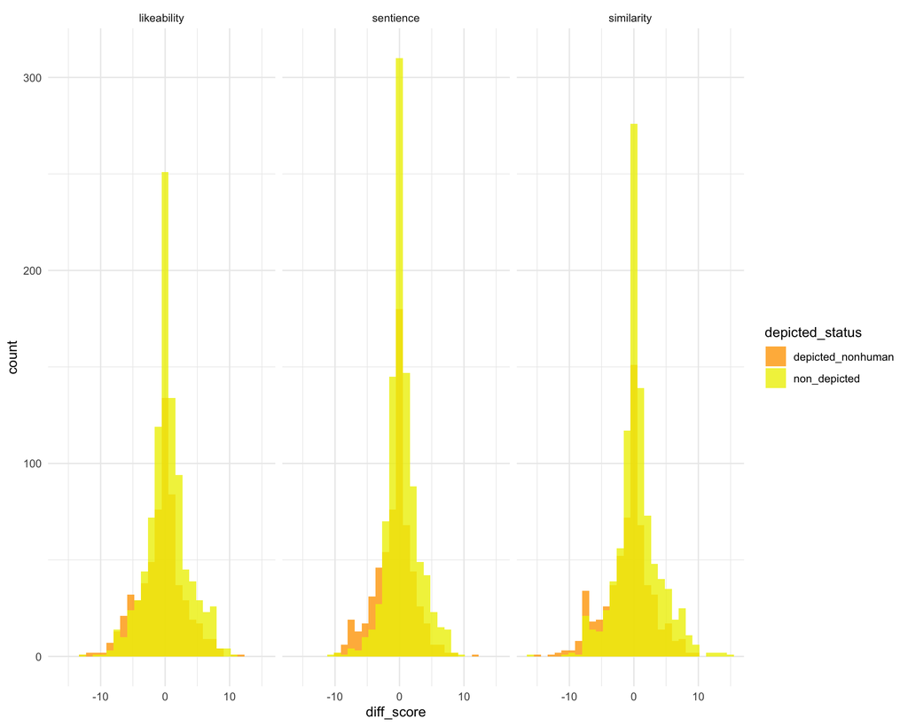

```r
# Plot depicted vs. not depicted, not considering human
rank_long |>
  filter(depicted_status != "human") |>
  ggplot(aes(diff_score, fill = depicted_status)) +
  geom_histogram(bins = 30, alpha = 0.8, position = "identity") +
  facet_wrap(~rating_type) +
  scale_fill_manual(values = c(
    "depicted_nonhuman" = "orange",
    "non_depicted" = "yellow2")) +
  theme_minimal()
```

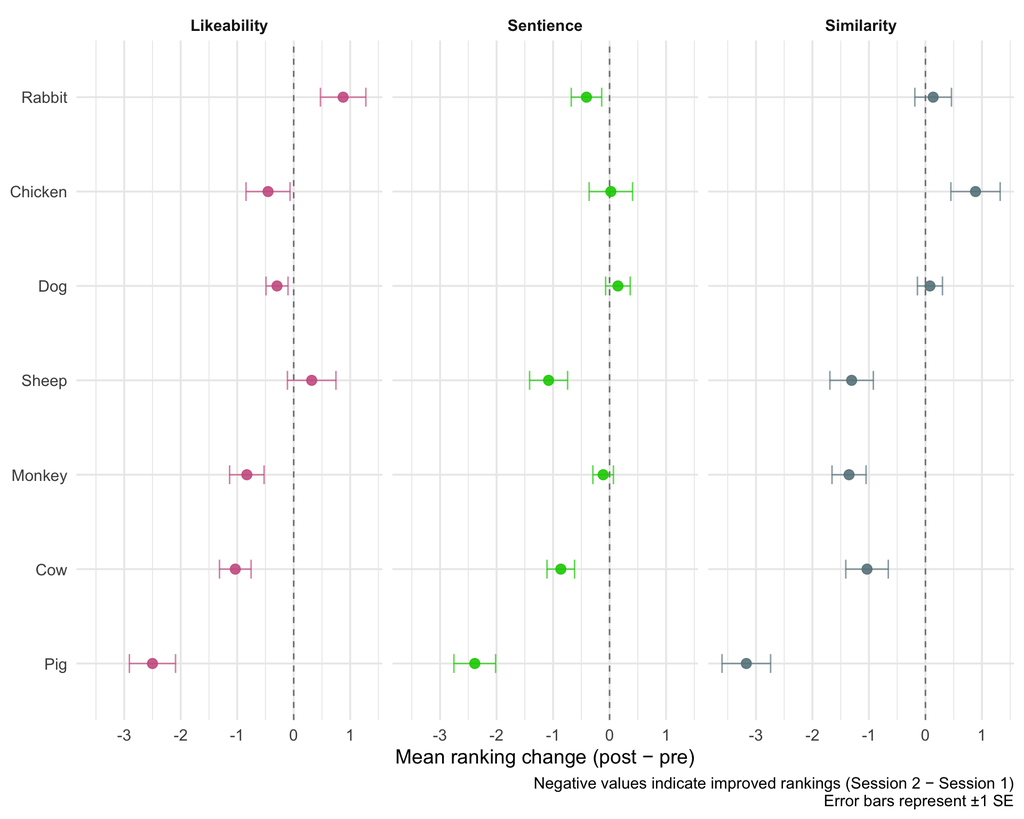

```r
# Mean difference scores for depicted animals only, by rating type and animal
depicted_means <- rank_long |>
  filter(depicted_status == "depicted_nonhuman") |>
  group_by(animal, rating_type) |>
  summarise(
    mean_diff = mean(diff_score, na.rm = TRUE),
    se_diff = sd(diff_score, na.rm = TRUE) / sqrt(n()),
    .groups = "drop"
  ) |>
  mutate(
    rating_type = factor(str_to_title(rating_type),
                        levels = c("Likeability", "Sentience", "Similarity")),
    animal = str_to_title(animal),
    animal = reorder(animal, mean_diff)
  )

ggplot(depicted_means, aes(x = mean_diff, y = animal, color = rating_type)) +
  geom_vline(xintercept = 0, linetype = "dashed", color = "gray50") +
  geom_errorbarh(aes(xmin = mean_diff - se_diff, xmax = mean_diff + se_diff),
                height = 0.2, alpha = 0.7) +
  geom_point(size = 3, alpha = 0.9) +
  facet_wrap(~rating_type, ncol = 3) +
  scale_color_manual(values = c(
    "Likeability" = "hotpink3",
    "Sentience" = "green3",
    "Similarity" = "lightblue4"
  )) +
  labs(caption = "Negative values indicate improved rankings (Session 2 − Session 1)\nError bars represent ±1 SE",
    x = "Mean ranking change (post − pre)",
    y = NULL
  ) +
  theme_minimal(base_size = 14) +
  theme(legend.position = "none",
        strip.text = element_text(face = "bold"))
```

Since 1 = “most liked/sentient/similar” and 19 = “least liked/sentient/similar”, negative difference scores mean that the ranking improved after watching the videos (ses2-ses1). The animal means df shows that pigs changed the most in ranking, becoming more likeable (mean of -2.5), sentient (-2.4), and similar (-3.2). The histogram of difference scores separated by depicted and non-depicted animals shows a normal distribution, though some depicted animals seem to have gotten better ratings after video watching as seen by the negative orange values.

Let’s do a t-test to see if it’s significant:

```r
# Depicted vs. non-depicted animals, pre to post
rank_long |>
  filter(depicted_status != "human") |>
  group_by(depicted_status, rating_type) |>
  summarise(mean_diff = mean(diff_score, na.rm = TRUE))
```

```
## # A tibble: 6 × 3
## # Groups:   depicted_status [2]
##   depicted_status   rating_type mean_diff
##   <chr>             <chr>           <dbl>
## 1 depicted_nonhuman likeability    -0.560
## 2 depicted_nonhuman sentience      -0.669
## 3 depicted_nonhuman similarity     -0.823
## 4 non_depicted      likeability     0.332
## 5 non_depicted      sentience       0.430
## 6 non_depicted      similarity      0.530
```

```r
t.test(diff_score ~ depicted_status, data = rank_long |> filter(depicted_status != "human"))
```

```
##
##  Welch Two Sample t-test
##
## data:  diff_score by depicted_status
## t = -11.801, df = 3582.9, p-value < 2.2e-16
## alternative hypothesis: true difference in means between group depicted_nonhuman and group non_depicted is not equal to 0
## 95 percent confidence interval:
##  -1.299576 -0.929271
## sample estimates:
## mean in group depicted_nonhuman      mean in group non_depicted
##                      -0.6839827                       0.4304408
```

Significant difference in rankings of depicted vs. non-depicted animals, t(3582.9) = -11.801, p < .001; depicted animals mean = -0.68 vs. non-depicted mean = 0.43.

# Semantic distance with FAST data and analyses

Let’s run FAST data through SemanticDistance

```r
# Clean FAST text using SemanticDistance package
sd_cleaned <- clean_monologue_or_list(fast_text_prompt, "text", omit_stops = TRUE, lemmatize = TRUE)

# Word-level semantic distances
sd_out <- dist_ngram2word(dat = sd_cleaned, ngram = 1)

# Check output
names(sd_out)
```

```
##  [1] "SubID"               "session_order"       "session_order_coded"
##  [4] "video_condition"     "session"             "prompt"
##  [7] "prompt_class"        "valence"             "doc_id"
## [10] "id_row_orig"         "text_initialsplit"   "word_clean"
## [13] "id_row_postsplit"    "CosDist_1gram_glo"   "CosDist_1gram_sd15"
```

```r
sd_out |> count(video_condition, prompt_class)
```

```
## # A tibble: 6 × 3
##   video_condition prompt_class         n
##   <fct>           <fct>            <int>
## 1 positive        stimulus_content  5309
## 2 positive        affect_term       7735
## 3 positive        control_term     18440
## 4 negative        stimulus_content  5388
## 5 negative        affect_term       7784
## 6 negative        control_term     18511
```

```r
# Average semantic distance for stimulus-related prompts only, removing NAs
sd_summary <- sd_out |>
  filter(prompt_class == "stimulus_content", !is.na(CosDist_1gram_glo)) |>
  group_by(SubID, session_order, session_order_coded, video_condition) |>
  summarise(mean_glo = mean(CosDist_1gram_glo, na.rm = TRUE),
            mean_sd15 = mean(CosDist_1gram_sd15, na.rm = TRUE),
            n_words = n(), .groups = "drop")

# Difference scores for condition context-effect: negative minus positive semantic distance for glove and sd15
semantic_context_df <- sd_summary |>
  pivot_wider(names_from = video_condition,
              values_from = c(mean_glo, mean_sd15, n_words)) |>
  mutate(semantic_context_glo = mean_glo_negative - mean_glo_positive,
         semantic_context_sd15 = mean_sd15_negative - mean_sd15_positive)

# Summary stats
semantic_context_df |>
  summarise(mean_glo = mean(semantic_context_glo, na.rm = TRUE),
            sd_glo = sd(semantic_context_glo, na.rm = TRUE),
            mean_sd15 = mean(semantic_context_sd15, na.rm = TRUE),
            sd_sd15 = sd(semantic_context_sd15, na.rm = TRUE),
            n = n())
```

```
## # A tibble: 1 × 5
##   mean_glo sd_glo mean_sd15 sd_sd15     n
##      <dbl>  <dbl>     <dbl>   <dbl> <int>
## 1 -0.00300 0.0789   -0.0304   0.118    88
```

```r
head(semantic_context_df)
```

```
## # A tibble: 6 × 11
##   SubID  session_order  session_order_coded mean_glo_positive mean_glo_negative
##   <chr>  <fct>                        <dbl>             <dbl>             <dbl>
## 1 sub001 positive_first                 0.5             0.642             0.640
## 2 sub002 positive_first                 0.5             0.666             0.701
## 3 sub003 positive_first                 0.5             0.773             0.647
## 4 sub004 negative_first                -0.5             0.718             0.728
## 5 sub005 negative_first                -0.5             0.633             0.734
## 6 sub006 negative_first                -0.5             0.677             0.682
## # ℹ 6 more variables: mean_sd15_positive <dbl>, mean_sd15_negative <dbl>,
## #   n_words_positive <int>, n_words_negative <int>, semantic_context_glo <dbl>,
## #   semantic_context_sd15 <dbl>
```

```r
# Test whether semantic context effects differ from zero
t.test(semantic_context_df$semantic_context_glo, mu = 0)
```

```
##
##  One Sample t-test
##
## data:  semantic_context_df$semantic_context_glo
## t = -0.35709, df = 87, p-value = 0.7219
## alternative hypothesis: true mean is not equal to 0
## 95 percent confidence interval:
##  -0.01970964  0.01370616
## sample estimates:
##    mean of x
## -0.003001739
```

```r
t.test(semantic_context_df$semantic_context_sd15, mu = 0)
```

```
##
##  One Sample t-test
##
## data:  semantic_context_df$semantic_context_sd15
## t = -2.4161, df = 87, p-value = 0.01778
## alternative hypothesis: true mean is not equal to 0
## 95 percent confidence interval:
##  -0.055386164 -0.005388976
## sample estimates:
##   mean of x
## -0.03038757
```

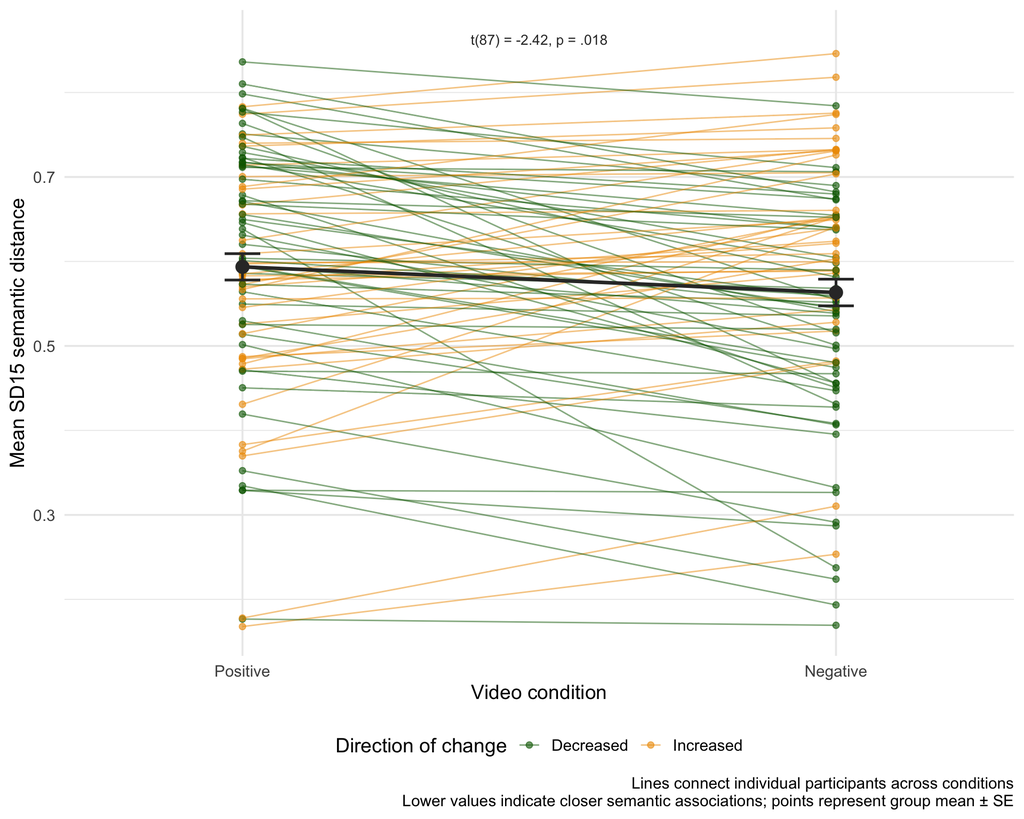

```r
# Plot
direction_df <- sd_summary |>
  select(SubID, video_condition, mean_sd15) |>
  pivot_wider(names_from = video_condition, values_from = mean_sd15) |>
  mutate(direction = if_else(negative < positive, "Decreased", "Increased")) |>
  select(SubID, direction)

paired_plot_df <- sd_summary |>
  mutate(video_condition = factor(str_to_title(as.character(video_condition)),
                                  levels = c("Positive", "Negative"))) |>
  left_join(direction_df, by = "SubID")

ggplot(paired_plot_df, aes(x = video_condition, y = mean_sd15, group = SubID)) +
  geom_line(aes(color = direction), alpha = 0.5, linewidth = 0.5) +
  geom_point(aes(color = direction), alpha = 0.6, size = 1.8) +
  stat_summary(aes(group = 1), fun = mean, geom = "line",
               linewidth = 1.2, color = "gray20") +
  stat_summary(aes(group = 1), fun = mean, geom = "point",
               size = 4, color = "gray20") +
  stat_summary(aes(group = 1), fun.data = mean_se, geom = "errorbar",
               width = 0.06, linewidth = 0.9, color = "gray20") +
  geom_text(data = data.frame(x = 1.5,
                               y = max(paired_plot_df$mean_sd15, na.rm = TRUE) * 1.02,
                               label = "t(87) = -2.42, p = .018"),
            aes(x = x, y = y, label = label),
            inherit.aes = FALSE, size = 3.5, color = "gray20") +
  scale_color_manual(values = c(
    "Increased" = "orange2",
    "Decreased" = "darkgreen")) +
  scale_x_discrete(expand = expansion(mult = 0.3)) +
  labs(
    caption = "Lines connect individual participants across conditions\nLower values indicate closer semantic associations; points represent group mean ± SE",
    x = "Video condition",
    y = "Mean SD15 semantic distance",
    color = "Direction of change"
  ) +
  theme_minimal(base_size = 14) +
  theme(legend.position = "bottom")
```

Semantic context effect is defined as the difference in semantic distance between negative and positive video conditions (negative − positive). There was semantic context effect for the sd15 but not Glove. Semantic representations were tighter (i.e., lower semantic distance) following negative video content compared to positive content.

## Big Kahuna: Are changes in animal rankings explaineed by changes in semantic representation?

Let’s see if changes in semantic representation explain the changes we see in animal rankings: drumroll please…..

```r
analysis_df <- rank_summary |>
  left_join(semantic_context_df |> select(SubID, semantic_context_sd15), by = "SubID")

model <- lm(mean_diff ~ semantic_context_sd15 * depicted_status + session_order_coded, data = analysis_df)
summary(model)
```

```
##
## Call:
## lm(formula = mean_diff ~ semantic_context_sd15 * depicted_status +
##     session_order_coded, data = analysis_df)
##
## Residuals:
##     Min      1Q  Median      3Q     Max
## -4.1552 -0.4180 -0.0064  0.4579  2.8580
##
## Coefficients:
##                                                        Estimate Std. Error
## (Intercept)                                             0.42779    0.05234
## semantic_context_sd15                                  -0.08723    0.43202
## depicted_statusdepicted_nonhuman                       -1.10809    0.07402
## session_order_coded                                    -0.03815    0.07169
## semantic_context_sd15:depicted_statusdepicted_nonhuman  0.20852    0.61082
##                                                        t value Pr(>|t|)
## (Intercept)                                              8.173 2.28e-15 ***
## semantic_context_sd15                                   -0.202    0.840
## depicted_statusdepicted_nonhuman                       -14.970  < 2e-16 ***
## session_order_coded                                     -0.532    0.595
## semantic_context_sd15:depicted_statusdepicted_nonhuman   0.341    0.733
## ---
## Signif. codes:  0 '***' 0.001 '**' 0.01 '*' 0.05 '.' 0.1 ' ' 1
##
## Residual standard error: 0.8233 on 523 degrees of freedom
## Multiple R-squared:  0.3166, Adjusted R-squared:  0.3114
## F-statistic: 60.57 on 4 and 523 DF,  p-value: < 2.2e-16
```

# Exploratory

Plots from my final presentation; visual exploration of the data as word frequency by condition, if there was a session order effect, Null finding of Big Kahuna with sd15,

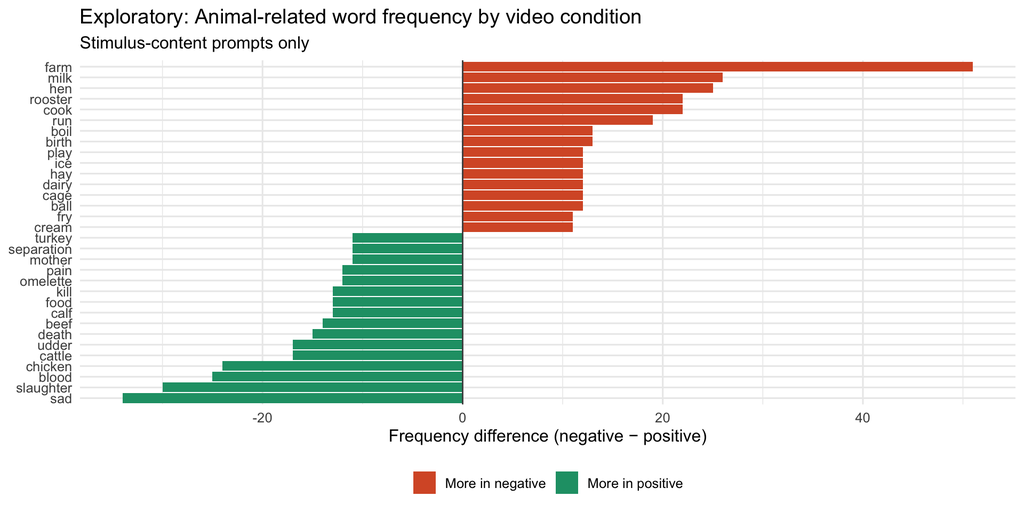

```r
# Word frequency :)
word_condition_diff <- fast_tokens_clean |>
  filter(prompt_class == "stimulus_content", !is.na(word_clean), word_clean != "") |>
  count(word_clean, video_condition) |>
  pivot_wider(names_from = video_condition, values_from = n, values_fill = 0) |>
  mutate(total = negative + positive,
         diff = negative - positive) |>
  filter(total >= 15) |>
  arrange(desc(diff))

word_condition_diff |>
  slice_max(abs(diff), n = 30) |>
  mutate(direction = if_else(diff > 0, "More in negative", "More in positive"),
         word_clean = reorder(word_clean, diff)) |>
  ggplot(aes(x = diff, y = word_clean, fill = direction)) +
  geom_col() +
  geom_vline(xintercept = 0, color = "gray30") +
  scale_fill_manual(values = c("More in negative" = "#D85A30", "More in positive" = "#1D9E75")) +
  labs(title = "Exploratory: Animal-related word frequency by video condition",
       subtitle = "Stimulus-content prompts only",
       x = "Frequency difference (negative − positive)",
       y = NULL,
       fill = NULL) +
  theme_minimal(base_size = 12) +
  theme(legend.position = "bottom")
```

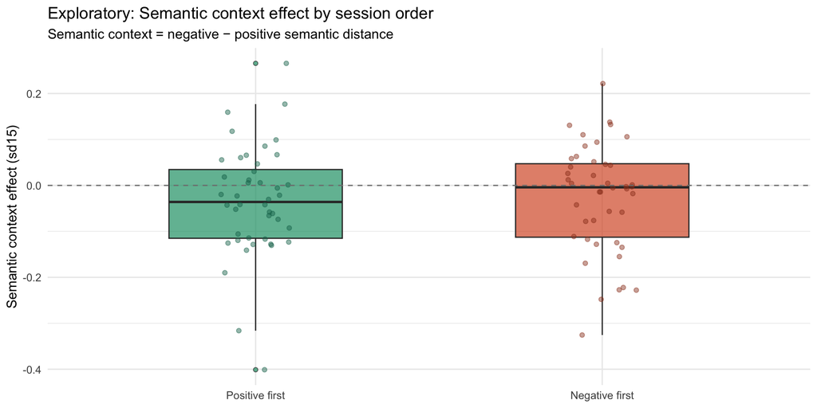

```r
# Is there a session order effect?
semantic_context_df |>
  mutate(session_order = recode(session_order,
                                "negative_first" = "Negative first",
                                "positive_first" = "Positive first")) |>
  ggplot(aes(x = session_order, y = semantic_context_sd15, fill = session_order)) +
  geom_boxplot(alpha = 0.7, outlier.shape = 21, width = 0.5) +
  geom_jitter(aes(color = session_order), width = 0.1, alpha = 0.45, size = 1.6) +
  geom_hline(yintercept = 0, linetype = "dashed", color = "gray50") +
  scale_fill_manual(values = c("Negative first" = "#D85A30", "Positive first" = "#1D9E75")) +
  scale_color_manual(values = c("Negative first" = "#993C1D", "Positive first" = "#0F6E56")) +
  labs(title = "Exploratory: Semantic context effect by session order",
       subtitle = "Semantic context = negative − positive semantic distance",
       x = NULL,
       y = "Semantic context effect (sd15)") +
  theme_minimal(base_size = 12) +
  theme(legend.position = "none")
```

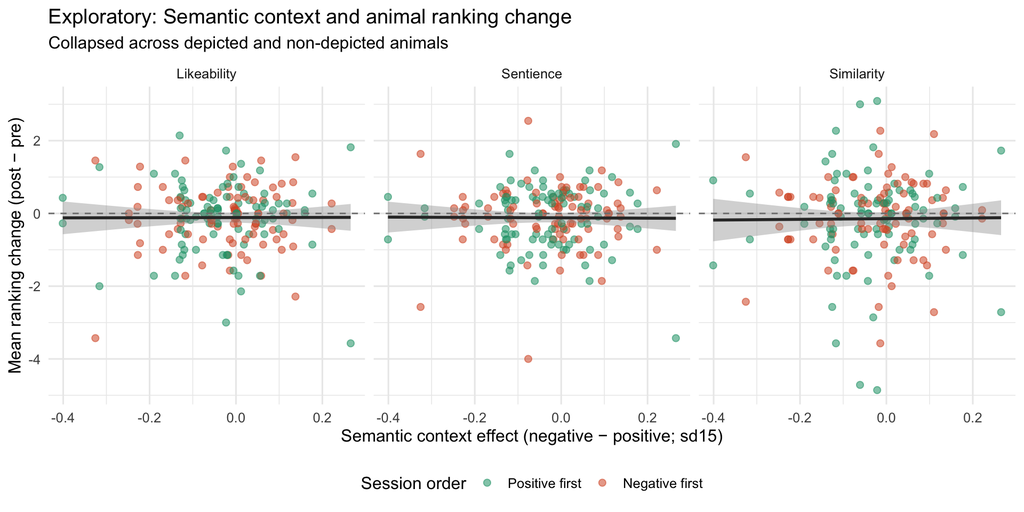

```r
# Big Kahuna lol
analysis_df <- rank_summary |>
  left_join(semantic_context_df |> select(SubID, semantic_context_sd15), by = "SubID")

analysis_df |>
  mutate(rating_type = str_to_title(rating_type),
         session_order = recode(session_order,
                                "negative_first" = "Negative first",
                                "positive_first" = "Positive first")) |>
  ggplot(aes(x = semantic_context_sd15, y = mean_diff)) +
  geom_point(aes(color = session_order), alpha = 0.55, size = 2) +
  geom_smooth(method = "lm", se = TRUE, color = "gray20", linewidth = 1) +
  geom_hline(yintercept = 0, linetype = "dashed", color = "gray50") +
  facet_wrap(~rating_type, ncol = 3) +
  scale_color_manual(values = c("Positive first" = "#1D9E75", "Negative first" = "#D85A30")) +
  labs(title = "Exploratory: Semantic context and animal ranking change",
       subtitle = "Collapsed across depicted and non-depicted animals",
       x = "Semantic context effect (negative − positive; sd15)",
       y = "Mean ranking change (post − pre)",
       color = "Session order") +
  theme_minimal(base_size = 12) +
  theme(legend.position = "bottom")
```

```r
##### Is FAST semantic distance different following positive vs negative condition?

h1_wide <- sd_out |>
  filter(prompt_class == "stimulus_content", !is.na(CosDist_1gram_sd15)) |>
  group_by(SubID, session_order, video_condition) |>
  summarise(mean_sd15 = mean(CosDist_1gram_sd15, na.rm = TRUE), .groups = "drop") |>
  pivot_wider(names_from = video_condition, values_from = mean_sd15) |>
  mutate(diff = negative - positive)

t.test(h1_wide$diff, mu = 0)
```

```
##
##  One Sample t-test
##
## data:  h1_wide$diff
## t = -2.4138, df = 87, p-value = 0.01789
## alternative hypothesis: true mean is not equal to 0
## 95 percent confidence interval:
##  -0.055376943 -0.005361672
## sample estimates:
##   mean of x
## -0.03036931
```

```r
model_sd15 <- lmer(mean_sd15 ~ video_condition + session_order + (1 | SubID), data = sd_summary)
summary(model_sd15)
```

```
## Linear mixed model fit by REML ['lmerMod']
## Formula: mean_sd15 ~ video_condition + session_order + (1 | SubID)
##    Data: sd_summary
##
## REML criterion at convergence: -212.5
##
## Scaled residuals:
##      Min       1Q   Median       3Q      Max
## -2.54385 -0.45932  0.07129  0.49106  1.89881
##
## Random effects:
##  Groups   Name        Variance Std.Dev.
##  SubID    (Intercept) 0.01492  0.12213
##  Residual             0.00696  0.08343
## Number of obs: 176, groups:  SubID, 88
##
## Fixed effects:
##                             Estimate Std. Error t value
## (Intercept)                  0.59539    0.02139  27.831
## video_conditionnegative     -0.03039    0.01258  -2.416
## session_ordernegative_first -0.00352    0.02892  -0.122
##
## Correlation of Fixed Effects:
##             (Intr) vd_cnd
## vd_cndtnngt -0.294
## sssn_rdrng_ -0.676  0.000
```

```r
h1_wide |>
  group_by(session_order) |>
  summarise(
    mean_diff = mean(diff, na.rm = TRUE),
    sd_diff = sd(diff, na.rm = TRUE),
    n = n(),
    p = t.test(diff, mu = 0)$p.value,
    .groups = "drop"
  )
```

```
## # A tibble: 2 × 5
##   session_order  mean_diff sd_diff     n      p
##   <fct>              <dbl>   <dbl> <int>  <dbl>
## 1 positive_first   -0.0339   0.120    44 0.0667
## 2 negative_first   -0.0268   0.118    44 0.138
```

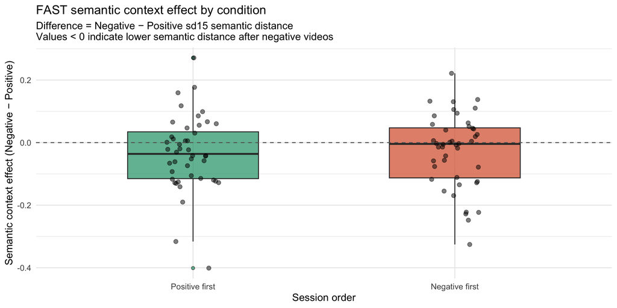

```r
h1_plot_df <- h1_wide |>
  mutate(session_order = recode(session_order,
                                "negative_first" = "Negative first",
                                "positive_first" = "Positive first"))

ggplot(h1_plot_df, aes(x = session_order, y = diff, fill = session_order)) +
  geom_boxplot(alpha = 0.7, width = 0.5, outlier.shape = 21) +
  geom_jitter(width = 0.1, alpha = 0.5, size = 2) +
  geom_hline(yintercept = 0, linetype = "dashed", color = "gray40") +
  scale_fill_manual(values = c("Negative first" = "#D85A30", "Positive first" = "#1D9E75")) +
  labs(
    title = "FAST semantic context effect by condition",
    subtitle = "Difference = Negative − Positive sd15 semantic distance\nValues < 0 indicate lower semantic distance after negative videos",
    x = "Session order",
    y = "Semantic context effect (Negative − Positive)"
  ) +
  theme_minimal(base_size = 12) +
  theme(legend.position = "none")
```

FAST responses following negative condition had lower semantic distance than those following positive condition, both with and without controlling for session order.